# IODS course project

Maria Litova

# Introduction to Open Data Science - Course Project

# About the project

I’m excited to have this course and hope to learn more on statistics and programming! My GitHub page: https://github.com/ntrmarie/IODS-project

# Linear regression analysis

1. The dataset learning2014 describes the approaches to learning. It includes 7 variables and 166 observations.

Let’s present the variables included into the dataset:

- gender: includes the male and female division of observations
- age: presents the age in years derived from the date of birth
- attitude: presents global attitude toward statistics
- stra: presents questions related to strategic learning
- surf: presents questions related to surface learning
- deep: presents questions related to deep learning
- points: presents the number of exam points

```r
learning2014 <- read.csv("/Users/Maria/R/IODS-project/data/learning2014.csv")
str(learning2014)
```

```
## 'data.frame':    166 obs. of  7 variables:
##  $ gender  : chr  "F" "M" "F" "M" ...
##  $ age     : int  53 55 49 53 49 38 50 37 37 42 ...
##  $ attitude: num  3.7 3.1 2.5 3.5 3.7 3.8 3.5 2.9 3.8 2.1 ...
##  $ deep    : num  3.58 2.92 3.5 3.5 3.67 ...
##  $ stra    : num  3.38 2.75 3.62 3.12 3.62 ...
##  $ surf    : num  2.58 3.17 2.25 2.25 2.83 ...
##  $ points  : int  25 12 24 10 22 21 21 31 24 26 ...
```

```r
dim(learning2014)
```

```
## [1] 166   7
```

2. Now we create graphical overview of the data

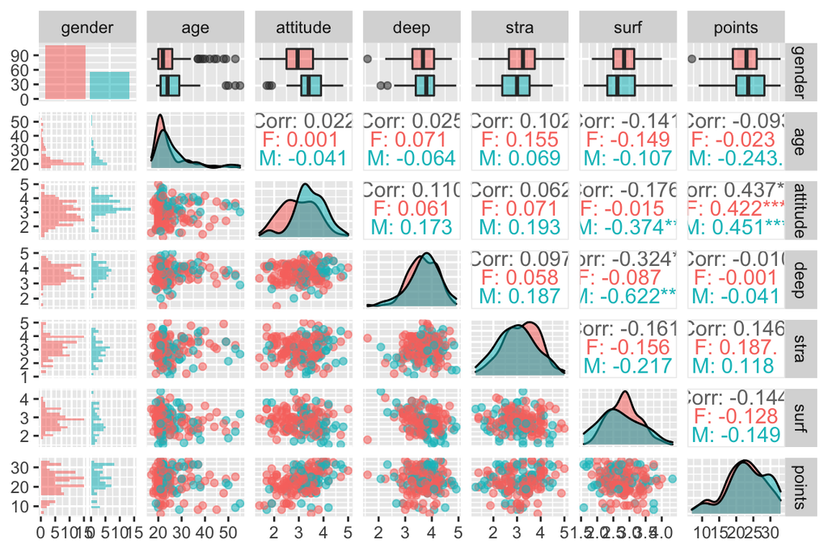

```r
library(ggplot2)
library(GGally)
# creates the plot matrix for the dataset
p <- ggpairs(learning2014, mapping = aes(col = gender, alpha = 0.3), lower = list(combo = wrap("facethist", bins = 20)))
p
```

Plots’ description:

The first line of box plots on the upper side presents the gender wise distribution of “age”, “attitude”, “deep”, “stra”, “surf” and “points”. Every plot includes lower and higher quartiles and median. Red colour shows female gender and blue colour - male gender. The first line also shows the gender distribution: the number of females(F) is twice bigger than males(M).

The upper triangle presents coefficients of correlation with gender. The lower triangle presents scatter plots for all the variables and show the relationship between every two variables. The plots based on the diagonal from left upper side to right upper side present the distribution of all the continuous variables in our scope.

In addition: Age distribution is skewed towards young people (mostly 20 years old).

3. Now we create regression model with multiple variables

```r
# creates regression model with three variables of highest (absolute) correlation with the target variable
my_model <- lm(points ~ attitude + stra + surf, data = learning2014)
```

```r
# shows the summary
summary(my_model)
```

```
##
## Call:
## lm(formula = points ~ attitude + stra + surf, data = learning2014)
##
## Residuals:
##      Min       1Q   Median       3Q      Max
## -17.1550  -3.4346   0.5156   3.6401  10.8952
##
## Coefficients:
##             Estimate Std. Error t value Pr(>|t|)
## (Intercept)  11.0171     3.6837   2.991  0.00322 **
## attitude      3.3952     0.5741   5.913 1.93e-08 ***
## stra          0.8531     0.5416   1.575  0.11716
## surf         -0.5861     0.8014  -0.731  0.46563
## ---
## Signif. codes:  0 '***' 0.001 '**' 0.01 '*' 0.05 '.' 0.1 ' ' 1
##
## Residual standard error: 5.296 on 162 degrees of freedom
## Multiple R-squared:  0.2074, Adjusted R-squared:  0.1927
## F-statistic: 14.13 on 3 and 162 DF,  p-value: 3.156e-08
```

Summary of the model:

- increase for 1 unit in “attitude” variable provides 3.4 units increase in points. The higher student’s attitude towards statistics, the higher grade he gains on the exam. Positive attitude is important for achievement.
- increase for 1 unit in “stra” (strategic learning approach) increases points by 0.9 units.
- increase for 1 unit in “surf” (surface learning approach) decreases points by 0.6 units.
- p-values show that only “attitude” is significant in the model on 5% significance level (p-values are less than 0.05) and “stra” and “surf” have p-values much higher than 0.05.

Therefore, the hypothesis that these parameters are equal to zero is accepted. It means that explanatory variable in our model doesn’t have a statistically significant relationship with the target variable. Now we need to fit another model without a “surf” variable:

```r
# creates regression model with two variables
my_model2 <- lm(points ~ attitude + stra, data = learning2014)
```

```r
# shows the summary
summary(my_model2)
```

```
##
## Call:
## lm(formula = points ~ attitude + stra, data = learning2014)
##
## Residuals:
##      Min       1Q   Median       3Q      Max
## -17.6436  -3.3113   0.5575   3.7928  10.9295
##
## Coefficients:
##             Estimate Std. Error t value Pr(>|t|)
## (Intercept)   8.9729     2.3959   3.745  0.00025 ***
## attitude      3.4658     0.5652   6.132 6.31e-09 ***
## stra          0.9137     0.5345   1.709  0.08927 .
## ---
## Signif. codes:  0 '***' 0.001 '**' 0.01 '*' 0.05 '.' 0.1 ' ' 1
##
## Residual standard error: 5.289 on 163 degrees of freedom
## Multiple R-squared:  0.2048, Adjusted R-squared:  0.1951
## F-statistic: 20.99 on 2 and 163 DF,  p-value: 7.734e-09
```

The new interpretation:

- increase for 1 unit in “attitude” variable provides 3.5 units increase in “points”. The higher student’s attitude towards statistics, the higher grade he gains on the exam.
- increase for 1 unit in “strategic learning approach” increases “points” by 0.9 units.

Multiple R-squared of the model: model explains 20% of variance in the data as far as $R^2 = 0.2$.

5.Produce the following diagnostic plots: Residuals vs Fitted values, Normal QQ-plot and Residuals vs Leverage.

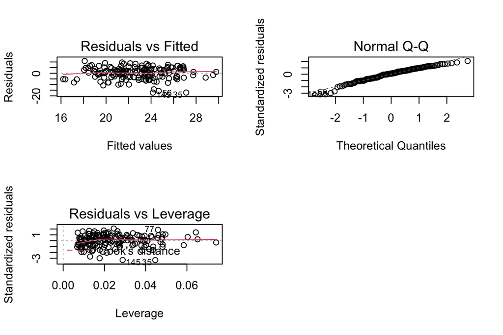

```r
# sets the plots' location
par(mfrow = c(2,2))
# creates diagnostic plots
plot(my_model, which=c(1,2,5))
```

# Logistic regression

## Data description

The data approach student achievement in secondary education of two Portuguese schools. We are interested in two datasets presenting the performance in Mathematics (math) and Portuguese language (por).

The whole information about data is presented here (https://archive.ics.uci.edu/ml/datasets/Student+Performance).

Having combined two datasets we will analyze the following variables:

- school - student’s school (binary: ‘GP’ - Gabriel Pereira or ‘MS’ - Mousinho da Silveira)
- sex - student’s sex (binary: ‘F’ - female or ‘M’ - male)
- age - student’s age (numeric: from 15 to 22)
- address - student’s home address type (binary: ‘U’ - urban or ‘R’ - rural)
- famsize - family size (binary: ‘LE3’ - less or equal to 3 or ‘GT3’ - greater than 3)
- Pstatus - parent’s cohabitation status (binary: ‘T’ - living together or ‘A’ - apart)
- Medu - mother’s education (numeric: 0 - none, 1 - primary education (4th grade), 2 – 5th to 9th grade, 3 – secondary education or 4 – higher education)
- Fedu - father’s education (numeric: 0 - none, 1 - primary education (4th grade), 2 – 5th to 9th grade, 3 – secondary education or 4 – higher education)
- Mjob - mother’s job (nominal: ‘teacher’, ‘health’ care related, civil ‘services’ (e.g. administrative or police), ‘at_home’ or ‘other’)
- Fjob - father’s job (nominal: ‘teacher’, ‘health’ care related, civil ‘services’ (e.g. administrative or police), ‘at_home’ or ‘other’)
- reason - reason to choose this school (nominal: close to ‘home’, school ‘reputation’, ‘course’ preference or ‘other’)
- guardian - student’s guardian (nominal: ‘mother’, ‘father’ or ‘other’)
- traveltime - home to school travel time (numeric: 1 - <15 min., 2 - 15 to 30 min., 3 - 30 min. to 1 hour, or 4 - >1 hour)
- studytime - weekly study time (numeric: 1 - <2 hours, 2 - 2 to 5 hours, 3 - 5 to 10 hours, or 4 - >10 hours)
- schoolsup - extra educational support (binary: yes or no)
- famsup - family educational support (binary: yes or no)
- activities - extra-curricular activities (binary: yes or no)
- nursery - attended nursery school (binary: yes or no)
- higher - wants to take higher education (binary: yes or no)
- internet - Internet access at home (binary: yes or no)
- romantic - with a romantic relationship (binary: yes or no)
- famrel - quality of family relationships (numeric: from 1 - very bad to 5 - excellent)
- freetime - free time after school (numeric: from 1 - very low to 5 - very high)
- goout - going out with friends (numeric: from 1 - very low to 5 - very high)
- Dalc - workday alcohol consumption (numeric: from 1 - very low to 5 - very high)
- Walc - weekend alcohol consumption (numeric: from 1 - very low to 5 - very high)
- health - current health status (numeric: from 1 - very bad to 5 - very good)
- failures - number of past class failures
- paid - extra paid classes within the course subject (Math or Portuguese)
- absences - number of school absences
- G1 - first period grade
- G2 - second period grade
- G3 - final grade

```r
# read the data
alc <- read.csv("/Users/Maria/R/IODS-project/data/alc.csv")
dim(alc)
```

```
## [1] 370  35
```

```r
colnames(alc)
```

```
##  [1] "school"     "sex"        "age"        "address"    "famsize"
##  [6] "Pstatus"    "Medu"       "Fedu"       "Mjob"       "Fjob"
## [11] "reason"     "guardian"   "traveltime" "studytime"  "schoolsup"
## [16] "famsup"     "activities" "nursery"    "higher"     "internet"
## [21] "romantic"   "famrel"     "freetime"   "goout"      "Dalc"
## [26] "Walc"       "health"     "failures"   "paid"       "absences"
## [31] "G1"         "G2"         "G3"         "alc_use"    "high_use"
```

```r
str(alc)
```

```
## 'data.frame':    370 obs. of  35 variables:
##  $ school    : chr  "GP" "GP" "GP" "GP" ...
##  $ sex       : chr  "F" "F" "F" "F" ...
##  $ age       : int  18 17 15 15 16 16 16 17 15 15 ...
##  $ address   : chr  "U" "U" "U" "U" ...
##  $ famsize   : chr  "GT3" "GT3" "LE3" "GT3" ...
##  $ Pstatus   : chr  "A" "T" "T" "T" ...
##  $ Medu      : int  4 1 1 4 3 4 2 4 3 3 ...
##  $ Fedu      : int  4 1 1 2 3 3 2 4 2 4 ...
##  $ Mjob      : chr  "at_home" "at_home" "at_home" "health" ...
##  $ Fjob      : chr  "teacher" "other" "other" "services" ...
##  $ reason    : chr  "course" "course" "other" "home" ...
##  $ guardian  : chr  "mother" "father" "mother" "mother" ...
##  $ traveltime: int  2 1 1 1 1 1 1 2 1 1 ...
##  $ studytime : int  2 2 2 3 2 2 2 2 2 2 ...
```

[output cut: 21 more lines]

## Hypothesis

The purpose of this part is to study the relationships between high/low alcohol consumption and some of the other variables in the data. Let’s choose 4 variables in the data and present four hypothesis about their relationships with alcohol consumption:

1. alcohol assumption decreases grades - **G1, G2, G3**
2. more free time students have, more alcohol they drink - **freetime**
3. alcohol assumption is increased by the number of school absences - **absences**
4. the worse relationships in the family, the higher alcohol assumption is - **famrel**

## Visualization and explanation

Let’s create the plots to explore our hypothesis:

```r
# count mean for the grades
alc$G <- (alc$G1 + alc$G2 + alc$G3)/3
```

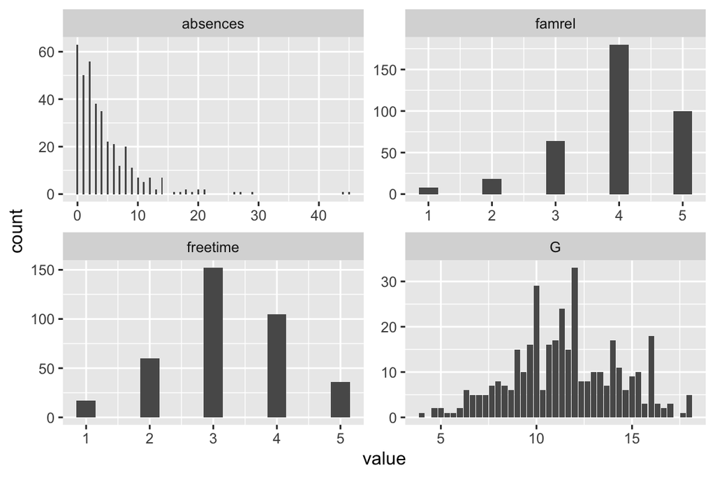

```r
# check the distribution with bar plots
bar <- select(alc, "G", "freetime", "absences", "famrel")
gather(bar) %>% ggplot(aes(value)) + facet_wrap("key", scales = "free") + geom_bar()
```

The plots show the following:

- the number of absences has only one peak that is in 0-10, so mainly students have 0 jr only several absences
- for main part of students quality of family relations can be estimated as good
- for main part of students amount of free time can be estimated as average and high
- the most frequent final grades are in 10-16 gap

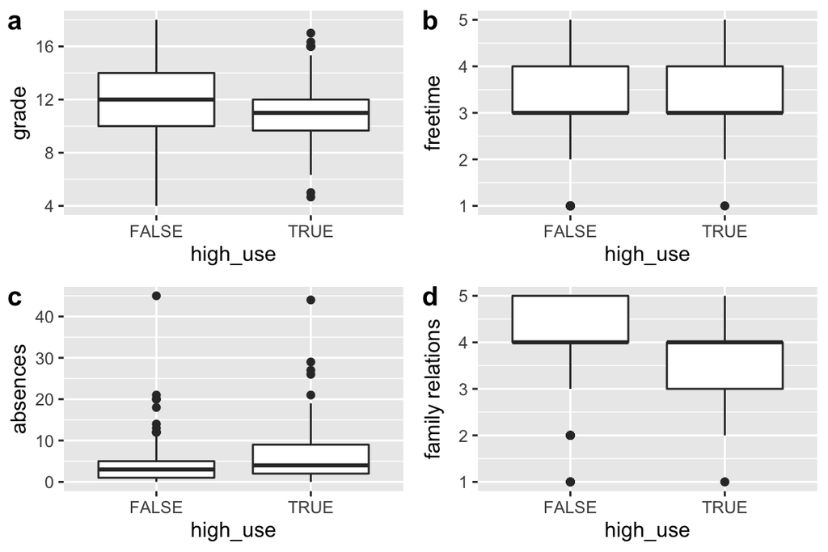

```r
# check the distribution with box plots
# for high_use variable TRUE is for students for which 'alc_use' is greater than 2, otherwise FALSE
# G is a mean grade
d1 <- ggplot(alc, aes(x = high_use, y = G)) + geom_boxplot() + ylab("grade")
d2 <- ggplot(alc, aes(x = high_use, y = freetime)) + geom_boxplot()
d3 <- ggplot(alc, aes(x = high_use, y = absences)) + geom_boxplot()
d4 <- ggplot(alc, aes(x = high_use, y = famrel)) + geom_boxplot() + ylab("family relations")

d <- plot_grid(d1, d2, d3, d4, labels = c('a', 'b', 'c', 'd'),align="hv")
d
```

The box plots show the following:

1. for mean grade and alcohol assumption(AA) plot the median for students with AA less than 2, is higher and there is an evidence that there are more students from this group that have higher mean grade, so we can confirm our hypothesis: alcohol assumption decreases grades
2. free time and alcohol assumption(AA) plot presents equal results, so we can’t confirm our hypothesis
3. for absences and alcohol assumption(AA) plot the median is mainly the same for both students’ groups and the number of absences is low. However, for those with AA grater than 2 we have more observations, so we can confirm our hypothesis: alcohol assumption is increased by the number of school absences
4. for family relations and alcohol assumption(AA) plot the median is the same and relations in families students mainly estimate as good but the group with AA more than 2, students estimate the relations worse, so we can assume that our hypothesis can be confirmed: the worse relationships in the family, the higher alcohol assumption is